# Risk Factor Analysis

## Outcome Variable

**Outcome Variable:** pers_wast

## Predictor Variables

**Intervention Variable:** meducyrs

**Adjustment Set:**

unadjusted

## Stratifying Variables

The analysis was stratified on these variable(s):

- agecat
- studyid
- country

## Data Summary

| agecat | studyid | country | meducyrs | pers_wast | n_cell | n |
| --- | --- | --- | --- | --- | --- | --- |
| 0-24 months | CMC-V-BCS-2002 | INDIA | High | 0 | 150 | 373 |
| 0-24 months | CMC-V-BCS-2002 | INDIA | High | 1 | 8 | 373 |
| 0-24 months | CMC-V-BCS-2002 | INDIA | Low | 0 | 98 | 373 |
| 0-24 months | CMC-V-BCS-2002 | INDIA | Low | 1 | 8 | 373 |
| 0-24 months | CMC-V-BCS-2002 | INDIA | Medium | 0 | 102 | 373 |
| 0-24 months | CMC-V-BCS-2002 | INDIA | Medium | 1 | 7 | 373 |
| 0-24 months | COHORTS | GUATEMALA | High | 0 | 203 | 1047 |
| 0-24 months | COHORTS | GUATEMALA | High | 1 | 6 | 1047 |
| 0-24 months | COHORTS | GUATEMALA | Low | 0 | 462 | 1047 |
| 0-24 months | COHORTS | GUATEMALA | Low | 1 | 20 | 1047 |
| 0-24 months | COHORTS | GUATEMALA | Medium | 0 | 346 | 1047 |
| 0-24 months | COHORTS | GUATEMALA | Medium | 1 | 10 | 1047 |
| 0-24 months | COHORTS | INDIA | High | 0 | 579 | 4519 |
| 0-24 months | COHORTS | INDIA | High | 1 | 31 | 4519 |
| 0-24 months | COHORTS | INDIA | Low | 0 | 1254 | 4519 |
| 0-24 months | COHORTS | INDIA | Low | 1 | 218 | 4519 |
| 0-24 months | COHORTS | INDIA | Medium | 0 | 2248 | 4519 |
| 0-24 months | COHORTS | INDIA | Medium | 1 | 189 | 4519 |
| 0-24 months | COHORTS | PHILIPPINES | High | 0 | 1013 | 2811 |
| 0-24 months | COHORTS | PHILIPPINES | High | 1 | 42 | 2811 |
| 0-24 months | COHORTS | PHILIPPINES | Low | 0 | 787 | 2811 |
| 0-24 months | COHORTS | PHILIPPINES | Low | 1 | 61 | 2811 |
| 0-24 months | COHORTS | PHILIPPINES | Medium | 0 | 867 | 2811 |
| 0-24 months | COHORTS | PHILIPPINES | Medium | 1 | 41 | 2811 |
| 0-24 months | EE | PAKISTAN | High | 0 | 15 | 374 |
| 0-24 months | EE | PAKISTAN | High | 1 | 0 | 374 |
| 0-24 months | EE | PAKISTAN | Low | 0 | 295 | 374 |
| 0-24 months | EE | PAKISTAN | Low | 1 | 31 | 374 |
| 0-24 months | EE | PAKISTAN | Medium | 0 | 31 | 374 |
| 0-24 months | EE | PAKISTAN | Medium | 1 | 2 | 374 |

[output cut: 366 more lines]

The following strata were considered:

- agecat: 0-24 months, studyid: CMC-V-BCS-2002, country: INDIA
- agecat: 0-24 months, studyid: COHORTS, country: GUATEMALA
- agecat: 0-24 months, studyid: COHORTS, country: INDIA
- agecat: 0-24 months, studyid: COHORTS, country: PHILIPPINES
- agecat: 0-24 months, studyid: EE, country: PAKISTAN
- agecat: 0-24 months, studyid: GMS-Nepal, country: NEPAL
- agecat: 0-24 months, studyid: Guatemala BSC, country: GUATEMALA
- agecat: 0-24 months, studyid: IRC, country: INDIA
- agecat: 0-24 months, studyid: LCNI-5, country: MALAWI
- agecat: 0-24 months, studyid: MAL-ED, country: BANGLADESH
- agecat: 0-24 months, studyid: MAL-ED, country: BRAZIL
- agecat: 0-24 months, studyid: MAL-ED, country: INDIA
- agecat: 0-24 months, studyid: MAL-ED, country: NEPAL
- agecat: 0-24 months, studyid: MAL-ED, country: PERU
- agecat: 0-24 months, studyid: MAL-ED, country: SOUTH AFRICA
- agecat: 0-24 months, studyid: MAL-ED, country: TANZANIA, UNITED REPUBLIC OF
- agecat: 0-24 months, studyid: NIH-Birth, country: BANGLADESH
- agecat: 0-24 months, studyid: NIH-Crypto, country: BANGLADESH
- agecat: 0-24 months, studyid: PROBIT, country: BELARUS
- agecat: 0-24 months, studyid: PROVIDE, country: BANGLADESH
- agecat: 0-24 months, studyid: SAS-CompFeed, country: INDIA
- agecat: 0-24 months, studyid: SAS-FoodSuppl, country: INDIA
- agecat: 0-24 months, studyid: TanzaniaChild2, country: TANZANIA, UNITED REPUBLIC OF
- agecat: 0-24 months, studyid: ZVITAMBO, country: ZIMBABWE
- agecat: 0-6 months, studyid: CMC-V-BCS-2002, country: INDIA
- agecat: 0-6 months, studyid: COHORTS, country: PHILIPPINES
- agecat: 0-6 months, studyid: EE, country: PAKISTAN
- agecat: 0-6 months, studyid: GMS-Nepal, country: NEPAL
- agecat: 0-6 months, studyid: IRC, country: INDIA
- agecat: 0-6 months, studyid: MAL-ED, country: BANGLADESH
- agecat: 0-6 months, studyid: MAL-ED, country: BRAZIL
- agecat: 0-6 months, studyid: MAL-ED, country: INDIA
- agecat: 0-6 months, studyid: MAL-ED, country: NEPAL
- agecat: 0-6 months, studyid: MAL-ED, country: PERU
- agecat: 0-6 months, studyid: MAL-ED, country: SOUTH AFRICA
- agecat: 0-6 months, studyid: MAL-ED, country: TANZANIA, UNITED REPUBLIC OF
- agecat: 0-6 months, studyid: NIH-Birth, country: BANGLADESH
- agecat: 0-6 months, studyid: NIH-Crypto, country: BANGLADESH
- agecat: 0-6 months, studyid: PROBIT, country: BELARUS
- agecat: 0-6 months, studyid: PROVIDE, country: BANGLADESH
- agecat: 0-6 months, studyid: TanzaniaChild2, country: TANZANIA, UNITED REPUBLIC OF
- agecat: 0-6 months, studyid: ZVITAMBO, country: ZIMBABWE
- agecat: 6-24 months, studyid: CMC-V-BCS-2002, country: INDIA
- agecat: 6-24 months, studyid: COHORTS, country: GUATEMALA
- agecat: 6-24 months, studyid: COHORTS, country: INDIA
- agecat: 6-24 months, studyid: COHORTS, country: PHILIPPINES
- agecat: 6-24 months, studyid: EE, country: PAKISTAN
- agecat: 6-24 months, studyid: GMS-Nepal, country: NEPAL
- agecat: 6-24 months, studyid: Guatemala BSC, country: GUATEMALA
- agecat: 6-24 months, studyid: IRC, country: INDIA
- agecat: 6-24 months, studyid: LCNI-5, country: MALAWI
- agecat: 6-24 months, studyid: MAL-ED, country: BANGLADESH
- agecat: 6-24 months, studyid: MAL-ED, country: BRAZIL
- agecat: 6-24 months, studyid: MAL-ED, country: INDIA
- agecat: 6-24 months, studyid: MAL-ED, country: NEPAL
- agecat: 6-24 months, studyid: MAL-ED, country: PERU
- agecat: 6-24 months, studyid: MAL-ED, country: SOUTH AFRICA
- agecat: 6-24 months, studyid: MAL-ED, country: TANZANIA, UNITED REPUBLIC OF
- agecat: 6-24 months, studyid: NIH-Birth, country: BANGLADESH
- agecat: 6-24 months, studyid: NIH-Crypto, country: BANGLADESH
- agecat: 6-24 months, studyid: PROBIT, country: BELARUS
- agecat: 6-24 months, studyid: PROVIDE, country: BANGLADESH
- agecat: 6-24 months, studyid: SAS-CompFeed, country: INDIA
- agecat: 6-24 months, studyid: SAS-FoodSuppl, country: INDIA
- agecat: 6-24 months, studyid: TanzaniaChild2, country: TANZANIA, UNITED REPUBLIC OF
- agecat: 6-24 months, studyid: ZVITAMBO, country: ZIMBABWE

### Dropped Strata

Some strata were dropped due to rare outcomes:

- agecat: 0-24 months, studyid: EE, country: PAKISTAN
- agecat: 0-24 months, studyid: Guatemala BSC, country: GUATEMALA
- agecat: 0-24 months, studyid: LCNI-5, country: MALAWI
- agecat: 0-24 months, studyid: MAL-ED, country: BANGLADESH
- agecat: 0-24 months, studyid: MAL-ED, country: BRAZIL
- agecat: 0-24 months, studyid: MAL-ED, country: INDIA
- agecat: 0-24 months, studyid: MAL-ED, country: NEPAL
- agecat: 0-24 months, studyid: MAL-ED, country: PERU
- agecat: 0-24 months, studyid: MAL-ED, country: SOUTH AFRICA
- agecat: 0-24 months, studyid: MAL-ED, country: TANZANIA, UNITED REPUBLIC OF
- agecat: 0-24 months, studyid: NIH-Crypto, country: BANGLADESH
- agecat: 0-24 months, studyid: PROVIDE, country: BANGLADESH
- agecat: 0-24 months, studyid: SAS-FoodSuppl, country: INDIA
- agecat: 0-24 months, studyid: TanzaniaChild2, country: TANZANIA, UNITED REPUBLIC OF
- agecat: 0-6 months, studyid: EE, country: PAKISTAN
- agecat: 0-6 months, studyid: MAL-ED, country: BANGLADESH
- agecat: 0-6 months, studyid: MAL-ED, country: BRAZIL
- agecat: 0-6 months, studyid: MAL-ED, country: NEPAL
- agecat: 0-6 months, studyid: MAL-ED, country: PERU
- agecat: 0-6 months, studyid: MAL-ED, country: SOUTH AFRICA
- agecat: 0-6 months, studyid: MAL-ED, country: TANZANIA, UNITED REPUBLIC OF
- agecat: 0-6 months, studyid: NIH-Birth, country: BANGLADESH
- agecat: 0-6 months, studyid: NIH-Crypto, country: BANGLADESH
- agecat: 0-6 months, studyid: PROVIDE, country: BANGLADESH
- agecat: 0-6 months, studyid: TanzaniaChild2, country: TANZANIA, UNITED REPUBLIC OF
- agecat: 0-6 months, studyid: ZVITAMBO, country: ZIMBABWE
- agecat: 6-24 months, studyid: EE, country: PAKISTAN
- agecat: 6-24 months, studyid: Guatemala BSC, country: GUATEMALA
- agecat: 6-24 months, studyid: LCNI-5, country: MALAWI
- agecat: 6-24 months, studyid: MAL-ED, country: BANGLADESH
- agecat: 6-24 months, studyid: MAL-ED, country: BRAZIL
- agecat: 6-24 months, studyid: MAL-ED, country: INDIA
- agecat: 6-24 months, studyid: MAL-ED, country: NEPAL
- agecat: 6-24 months, studyid: MAL-ED, country: PERU
- agecat: 6-24 months, studyid: MAL-ED, country: SOUTH AFRICA
- agecat: 6-24 months, studyid: MAL-ED, country: TANZANIA, UNITED REPUBLIC OF
- agecat: 6-24 months, studyid: NIH-Crypto, country: BANGLADESH
- agecat: 6-24 months, studyid: PROVIDE, country: BANGLADESH
- agecat: 6-24 months, studyid: SAS-FoodSuppl, country: INDIA
- agecat: 6-24 months, studyid: TanzaniaChild2, country: TANZANIA, UNITED REPUBLIC OF

## Methods Detail

We’re interested in the causal parameters $E[Y_a]$ for all values of $a \in \mathcal{A}$. These parameters represent the mean outcome if, possibly contrary to fact, we intervened to set all units to have $A=a$. Under the randomization and positivity assumptions, these are identified by the statistical parameters $\psi_a=E_W[E_{Y|A,W}(Y|A=a,W)]$. In addition, we’re interested in the mean of $Y$, $E[Y]$ under no intervention (the observed mean). We will estimate these parameters by using SuperLearner to fit the relevant likelihood factors – $E_{Y|A,W}(Y|A=a,W)$ and $p(A=a|W)$, and then updating our likelihood fit using a joint TMLE.

For unadjusted analyses ($W=\{\}$), initial likelihoods were estimated using Lrnr_glm to estimate the simple $E(Y|A)$ and Lrnr_mean to estimate $p(A)$. For adjusted analyses, a small library containing Lrnr_glmnet, Lrnr_xgboost, and Lrnr_mean was used.

Having estimated these parameters, we will then use the delta method to estimate relative risks and attributable risks relative to a prespecified baseline level of $A$.

# Results Detail

## Results Plots

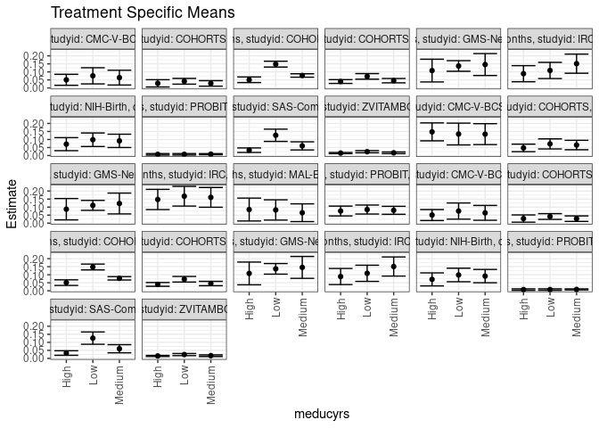

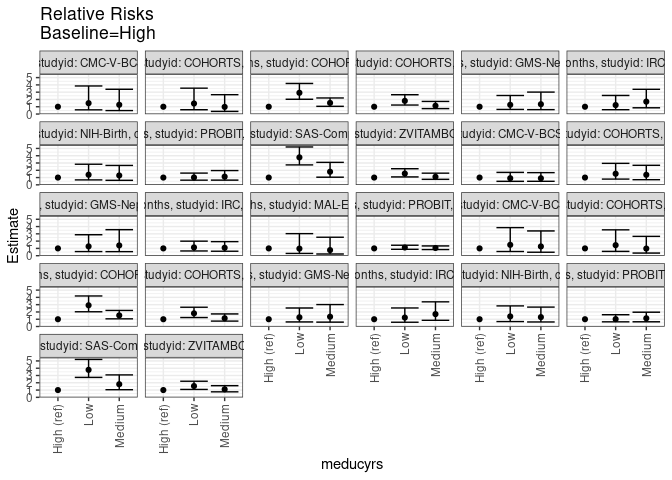

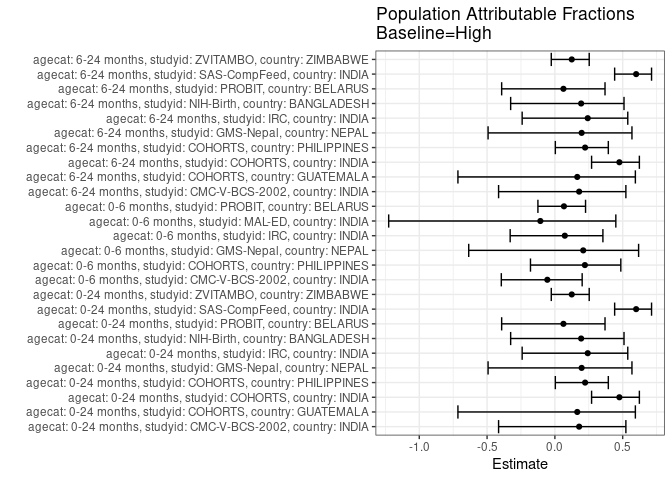

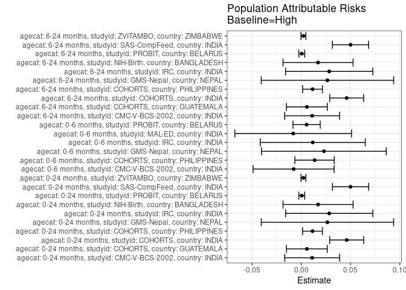

## Results Table

### Parameter: TSM

| agecat | studyid | country | intervention_level | baseline_level | estimate | ci_lower | ci_upper |
| --- | --- | --- | --- | --- | --- | --- | --- |
| 0-24 months | CMC-V-BCS-2002 | INDIA | High | NA | 0.0506329 | 0.0164006 | 0.0848652 |
| 0-24 months | CMC-V-BCS-2002 | INDIA | Low | NA | 0.0754717 | 0.0251181 | 0.1258253 |
| 0-24 months | CMC-V-BCS-2002 | INDIA | Medium | NA | 0.0642202 | 0.0181372 | 0.1103031 |
| 0-24 months | COHORTS | GUATEMALA | High | NA | 0.0287081 | 0.0060586 | 0.0513577 |
| 0-24 months | COHORTS | GUATEMALA | Low | NA | 0.0414938 | 0.0236814 | 0.0593061 |
| 0-24 months | COHORTS | GUATEMALA | Medium | NA | 0.0280899 | 0.0109180 | 0.0452618 |
| 0-24 months | COHORTS | INDIA | High | NA | 0.0508197 | 0.0333887 | 0.0682506 |
| 0-24 months | COHORTS | INDIA | Low | NA | 0.1480978 | 0.1299505 | 0.1662451 |
| 0-24 months | COHORTS | INDIA | Medium | NA | 0.0775544 | 0.0669339 | 0.0881748 |
| 0-24 months | COHORTS | PHILIPPINES | High | NA | 0.0398104 | 0.0280106 | 0.0516103 |
| 0-24 months | COHORTS | PHILIPPINES | Low | NA | 0.0719340 | 0.0545406 | 0.0893273 |
| 0-24 months | COHORTS | PHILIPPINES | Medium | NA | 0.0451542 | 0.0316460 | 0.0586624 |
| 0-24 months | GMS-Nepal | NEPAL | High | NA | 0.1081081 | 0.0372999 | 0.1789163 |
| 0-24 months | GMS-Nepal | NEPAL | Low | NA | 0.1366906 | 0.1036918 | 0.1696895 |
| 0-24 months | GMS-Nepal | NEPAL | Medium | NA | 0.1456311 | 0.0774529 | 0.2138092 |
| 0-24 months | IRC | INDIA | High | NA | 0.0887097 | 0.0386046 | 0.1388147 |
| 0-24 months | IRC | INDIA | Low | NA | 0.1088435 | 0.0584357 | 0.1592514 |
| 0-24 months | IRC | INDIA | Medium | NA | 0.1510791 | 0.0914708 | 0.2106874 |
| 0-24 months | NIH-Birth | BANGLADESH | High | NA | 0.0709677 | 0.0305069 | 0.1114286 |
| 0-24 months | NIH-Birth | BANGLADESH | Low | NA | 0.0984456 | 0.0563758 | 0.1405154 |
| 0-24 months | NIH-Birth | BANGLADESH | Medium | NA | 0.0913978 | 0.0499451 | 0.1328506 |
| 0-24 months | PROBIT | BELARUS | High | NA | 0.0075703 | 0.0028518 | 0.0122888 |
| 0-24 months | PROBIT | BELARUS | Low | NA | 0.0077078 | 0.0031093 | 0.0123063 |
| 0-24 months | PROBIT | BELARUS | Medium | NA | 0.0085448 | 0.0051549 | 0.0119347 |
| 0-24 months | SAS-CompFeed | INDIA | High | NA | 0.0334448 | 0.0193394 | 0.0475503 |
| 0-24 months | SAS-CompFeed | INDIA | Low | NA | 0.1262458 | 0.0879874 | 0.1645043 |
| 0-24 months | SAS-CompFeed | INDIA | Medium | NA | 0.0602151 | 0.0348628 | 0.0855673 |
| 0-24 months | ZVITAMBO | ZIMBABWE | High | NA | 0.0154629 | 0.0120794 | 0.0188464 |
| 0-24 months | ZVITAMBO | ZIMBABWE | Low | NA | 0.0239880 | 0.0172834 | 0.0306926 |
| 0-24 months | ZVITAMBO | ZIMBABWE | Medium | NA | 0.0170620 | 0.0118839 | 0.0222401 |
| 0-6 months | CMC-V-BCS-2002 | INDIA | High | NA | 0.1474359 | 0.0917227 | 0.2031491 |
| 0-6 months | CMC-V-BCS-2002 | INDIA | Low | NA | 0.1340206 | 0.0661301 | 0.2019112 |
| 0-6 months | CMC-V-BCS-2002 | INDIA | Medium | NA | 0.1333333 | 0.0682220 | 0.1984446 |
| 0-6 months | COHORTS | PHILIPPINES | High | NA | 0.0474684 | 0.0240098 | 0.0709269 |
| 0-6 months | COHORTS | PHILIPPINES | Low | NA | 0.0725191 | 0.0410973 | 0.1039409 |
| 0-6 months | COHORTS | PHILIPPINES | Medium | NA | 0.0654545 | 0.0362058 | 0.0947032 |
| 0-6 months | GMS-Nepal | NEPAL | High | NA | 0.0869565 | 0.0204130 | 0.1535000 |
| 0-6 months | GMS-Nepal | NEPAL | Low | NA | 0.1108312 | 0.0799239 | 0.1417386 |
| 0-6 months | GMS-Nepal | NEPAL | Medium | NA | 0.1224490 | 0.0574907 | 0.1874072 |
| 0-6 months | IRC | INDIA | High | NA | 0.1475410 | 0.0845321 | 0.2105499 |
| 0-6 months | IRC | INDIA | Low | NA | 0.1678322 | 0.1065034 | 0.2291609 |
| 0-6 months | IRC | INDIA | Medium | NA | 0.1605839 | 0.0990282 | 0.2221397 |
| 0-6 months | MAL-ED | INDIA | High | NA | 0.0847458 | 0.0135108 | 0.1559808 |
| 0-6 months | MAL-ED | INDIA | Low | NA | 0.0821918 | 0.0190352 | 0.1453483 |
| 0-6 months | MAL-ED | INDIA | Medium | NA | 0.0649351 | 0.0097648 | 0.1201053 |
| 0-6 months | PROBIT | BELARUS | High | NA | 0.0756341 | 0.0450184 | 0.1062497 |
| 0-6 months | PROBIT | BELARUS | Low | NA | 0.0848861 | 0.0570015 | 0.1127708 |
| 0-6 months | PROBIT | BELARUS | Medium | NA | 0.0800493 | 0.0552003 | 0.1048982 |
| 6-24 months | CMC-V-BCS-2002 | INDIA | High | NA | 0.0506329 | 0.0164006 | 0.0848652 |
| 6-24 months | CMC-V-BCS-2002 | INDIA | Low | NA | 0.0754717 | 0.0251181 | 0.1258253 |
| 6-24 months | CMC-V-BCS-2002 | INDIA | Medium | NA | 0.0642202 | 0.0181372 | 0.1103031 |
| 6-24 months | COHORTS | GUATEMALA | High | NA | 0.0287081 | 0.0060586 | 0.0513577 |
| 6-24 months | COHORTS | GUATEMALA | Low | NA | 0.0414938 | 0.0236814 | 0.0593061 |
| 6-24 months | COHORTS | GUATEMALA | Medium | NA | 0.0280899 | 0.0109180 | 0.0452618 |
| 6-24 months | COHORTS | INDIA | High | NA | 0.0508197 | 0.0333887 | 0.0682506 |
| 6-24 months | COHORTS | INDIA | Low | NA | 0.1480978 | 0.1299505 | 0.1662451 |
| 6-24 months | COHORTS | INDIA | Medium | NA | 0.0775544 | 0.0669339 | 0.0881748 |
| 6-24 months | COHORTS | PHILIPPINES | High | NA | 0.0398104 | 0.0280106 | 0.0516103 |
| 6-24 months | COHORTS | PHILIPPINES | Low | NA | 0.0719340 | 0.0545406 | 0.0893273 |
| 6-24 months | COHORTS | PHILIPPINES | Medium | NA | 0.0451542 | 0.0316460 | 0.0586624 |
| 6-24 months | GMS-Nepal | NEPAL | High | NA | 0.1081081 | 0.0372999 | 0.1789163 |
| 6-24 months | GMS-Nepal | NEPAL | Low | NA | 0.1366906 | 0.1036918 | 0.1696895 |
| 6-24 months | GMS-Nepal | NEPAL | Medium | NA | 0.1456311 | 0.0774529 | 0.2138092 |
| 6-24 months | IRC | INDIA | High | NA | 0.0887097 | 0.0386046 | 0.1388147 |
| 6-24 months | IRC | INDIA | Low | NA | 0.1088435 | 0.0584357 | 0.1592514 |
| 6-24 months | IRC | INDIA | Medium | NA | 0.1510791 | 0.0914708 | 0.2106874 |
| 6-24 months | NIH-Birth | BANGLADESH | High | NA | 0.0709677 | 0.0305069 | 0.1114286 |
| 6-24 months | NIH-Birth | BANGLADESH | Low | NA | 0.0984456 | 0.0563758 | 0.1405154 |
| 6-24 months | NIH-Birth | BANGLADESH | Medium | NA | 0.0913978 | 0.0499451 | 0.1328506 |
| 6-24 months | PROBIT | BELARUS | High | NA | 0.0075703 | 0.0028518 | 0.0122888 |
| 6-24 months | PROBIT | BELARUS | Low | NA | 0.0077078 | 0.0031093 | 0.0123063 |
| 6-24 months | PROBIT | BELARUS | Medium | NA | 0.0085448 | 0.0051549 | 0.0119347 |
| 6-24 months | SAS-CompFeed | INDIA | High | NA | 0.0334448 | 0.0193394 | 0.0475503 |
| 6-24 months | SAS-CompFeed | INDIA | Low | NA | 0.1262458 | 0.0879874 | 0.1645043 |
| 6-24 months | SAS-CompFeed | INDIA | Medium | NA | 0.0602151 | 0.0348628 | 0.0855673 |
| 6-24 months | ZVITAMBO | ZIMBABWE | High | NA | 0.0154629 | 0.0120794 | 0.0188464 |
| 6-24 months | ZVITAMBO | ZIMBABWE | Low | NA | 0.0239880 | 0.0172834 | 0.0306926 |
| 6-24 months | ZVITAMBO | ZIMBABWE | Medium | NA | 0.0170620 | 0.0118839 | 0.0222401 |

### Parameter: E(Y)

| agecat | studyid | country | intervention_level | baseline_level | estimate | ci_lower | ci_upper |
| --- | --- | --- | --- | --- | --- | --- | --- |
| 0-24 months | CMC-V-BCS-2002 | INDIA | NA | NA | 0.0616622 | 0.0372186 | 0.0861058 |
| 0-24 months | COHORTS | GUATEMALA | NA | NA | 0.0343840 | 0.0233416 | 0.0454263 |
| 0-24 months | COHORTS | INDIA | NA | NA | 0.0969241 | 0.0882972 | 0.1055510 |
| 0-24 months | COHORTS | PHILIPPINES | NA | NA | 0.0512273 | 0.0430760 | 0.0593786 |
| 0-24 months | GMS-Nepal | NEPAL | NA | NA | 0.1346801 | 0.1072037 | 0.1621566 |
| 0-24 months | IRC | INDIA | NA | NA | 0.1170732 | 0.0859146 | 0.1482317 |
| 0-24 months | NIH-Birth | BANGLADESH | NA | NA | 0.0880150 | 0.0639627 | 0.1120673 |
| 0-24 months | PROBIT | BELARUS | NA | NA | 0.0080806 | 0.0045539 | 0.0116073 |
| 0-24 months | SAS-CompFeed | INDIA | NA | NA | 0.0834553 | 0.0601989 | 0.1067118 |
| 0-24 months | ZVITAMBO | ZIMBABWE | NA | NA | 0.0176600 | 0.0150131 | 0.0203070 |
| 0-6 months | CMC-V-BCS-2002 | INDIA | NA | NA | 0.1396648 | 0.1037072 | 0.1756225 |
| 0-6 months | COHORTS | PHILIPPINES | NA | NA | 0.0609613 | 0.0448957 | 0.0770269 |
| 0-6 months | GMS-Nepal | NEPAL | NA | NA | 0.1099291 | 0.0840909 | 0.1357673 |
| 0-6 months | IRC | INDIA | NA | NA | 0.1592040 | 0.1233945 | 0.1950135 |
| 0-6 months | MAL-ED | INDIA | NA | NA | 0.0765550 | 0.0404216 | 0.1126884 |
| 0-6 months | PROBIT | BELARUS | NA | NA | 0.0810551 | 0.0555982 | 0.1065120 |
| 6-24 months | CMC-V-BCS-2002 | INDIA | NA | NA | 0.0616622 | 0.0372186 | 0.0861058 |
| 6-24 months | COHORTS | GUATEMALA | NA | NA | 0.0343840 | 0.0233416 | 0.0454263 |
| 6-24 months | COHORTS | INDIA | NA | NA | 0.0969241 | 0.0882972 | 0.1055510 |
| 6-24 months | COHORTS | PHILIPPINES | NA | NA | 0.0512273 | 0.0430760 | 0.0593786 |
| 6-24 months | GMS-Nepal | NEPAL | NA | NA | 0.1346801 | 0.1072037 | 0.1621566 |
| 6-24 months | IRC | INDIA | NA | NA | 0.1170732 | 0.0859146 | 0.1482317 |
| 6-24 months | NIH-Birth | BANGLADESH | NA | NA | 0.0880150 | 0.0639627 | 0.1120673 |
| 6-24 months | PROBIT | BELARUS | NA | NA | 0.0080806 | 0.0045539 | 0.0116073 |
| 6-24 months | SAS-CompFeed | INDIA | NA | NA | 0.0834553 | 0.0601989 | 0.1067118 |
| 6-24 months | ZVITAMBO | ZIMBABWE | NA | NA | 0.0176600 | 0.0150131 | 0.0203070 |

### Parameter: RR

| agecat | studyid | country | intervention_level | baseline_level | estimate | ci_lower | ci_upper |
| --- | --- | --- | --- | --- | --- | --- | --- |
| 0-24 months | CMC-V-BCS-2002 | INDIA | High | High | 1.0000000 | 1.0000000 | 1.000000 |
| 0-24 months | CMC-V-BCS-2002 | INDIA | Low | High | 1.4905660 | 0.5765449 | 3.853624 |
| 0-24 months | CMC-V-BCS-2002 | INDIA | Medium | High | 1.2683486 | 0.4732218 | 3.399481 |
| 0-24 months | COHORTS | GUATEMALA | High | High | 1.0000000 | 1.0000000 | 1.000000 |
| 0-24 months | COHORTS | GUATEMALA | Low | High | 1.4453665 | 0.5887096 | 3.548582 |
| 0-24 months | COHORTS | GUATEMALA | Medium | High | 0.9784644 | 0.3606476 | 2.654648 |
| 0-24 months | COHORTS | INDIA | High | High | 1.0000000 | 1.0000000 | 1.000000 |
| 0-24 months | COHORTS | INDIA | Low | High | 2.9141830 | 2.0245797 | 4.194679 |
| 0-24 months | COHORTS | INDIA | Medium | High | 1.5260699 | 1.0548225 | 2.207849 |
| 0-24 months | COHORTS | PHILIPPINES | High | High | 1.0000000 | 1.0000000 | 1.000000 |
| 0-24 months | COHORTS | PHILIPPINES | Low | High | 1.8069126 | 1.2325721 | 2.648878 |
| 0-24 months | COHORTS | PHILIPPINES | Medium | High | 1.1342301 | 0.7444023 | 1.728203 |
| 0-24 months | GMS-Nepal | NEPAL | High | High | 1.0000000 | 1.0000000 | 1.000000 |
| 0-24 months | GMS-Nepal | NEPAL | Low | High | 1.2643885 | 0.6291027 | 2.541204 |
| 0-24 months | GMS-Nepal | NEPAL | Medium | High | 1.3470874 | 0.6022147 | 3.013285 |
| 0-24 months | IRC | INDIA | High | High | 1.0000000 | 1.0000000 | 1.000000 |
| 0-24 months | IRC | INDIA | Low | High | 1.2269635 | 0.5910402 | 2.547102 |
| 0-24 months | IRC | INDIA | Medium | High | 1.7030739 | 0.8550937 | 3.391980 |
| 0-24 months | NIH-Birth | BANGLADESH | High | High | 1.0000000 | 1.0000000 | 1.000000 |
| 0-24 months | NIH-Birth | BANGLADESH | Low | High | 1.3871879 | 0.6802941 | 2.828616 |
| 0-24 months | NIH-Birth | BANGLADESH | Medium | High | 1.2878788 | 0.6215563 | 2.668514 |
| 0-24 months | PROBIT | BELARUS | High | High | 1.0000000 | 1.0000000 | 1.000000 |
| 0-24 months | PROBIT | BELARUS | Low | High | 1.0181603 | 0.6413291 | 1.616410 |
| 0-24 months | PROBIT | BELARUS | Medium | High | 1.1287312 | 0.6485367 | 1.964475 |
| 0-24 months | SAS-CompFeed | INDIA | High | High | 1.0000000 | 1.0000000 | 1.000000 |
| 0-24 months | SAS-CompFeed | INDIA | Low | High | 3.7747508 | 2.7376990 | 5.204642 |
| 0-24 months | SAS-CompFeed | INDIA | Medium | High | 1.8004301 | 1.0507403 | 3.085014 |
| 0-24 months | ZVITAMBO | ZIMBABWE | High | High | 1.0000000 | 1.0000000 | 1.000000 |
| 0-24 months | ZVITAMBO | ZIMBABWE | Low | High | 1.5513256 | 1.0877896 | 2.212387 |
| 0-24 months | ZVITAMBO | ZIMBABWE | Medium | High | 1.1034150 | 0.7590141 | 1.604087 |
| 0-6 months | CMC-V-BCS-2002 | INDIA | High | High | 1.0000000 | 1.0000000 | 1.000000 |
| 0-6 months | CMC-V-BCS-2002 | INDIA | Low | High | 0.9090094 | 0.4831709 | 1.710157 |
| 0-6 months | CMC-V-BCS-2002 | INDIA | Medium | High | 0.9043478 | 0.4877230 | 1.676864 |
| 0-6 months | COHORTS | PHILIPPINES | High | High | 1.0000000 | 1.0000000 | 1.000000 |
| 0-6 months | COHORTS | PHILIPPINES | Low | High | 1.5277354 | 0.7917928 | 2.947710 |
| 0-6 months | COHORTS | PHILIPPINES | Medium | High | 1.3789091 | 0.7082413 | 2.684665 |
| 0-6 months | GMS-Nepal | NEPAL | High | High | 1.0000000 | 1.0000000 | 1.000000 |
| 0-6 months | GMS-Nepal | NEPAL | Low | High | 1.2745592 | 0.5644642 | 2.877953 |
| 0-6 months | GMS-Nepal | NEPAL | Medium | High | 1.4081633 | 0.5549605 | 3.573090 |
| 0-6 months | IRC | INDIA | High | High | 1.0000000 | 1.0000000 | 1.000000 |
| 0-6 months | IRC | INDIA | Low | High | 1.1375291 | 0.6484305 | 1.995545 |
| 0-6 months | IRC | INDIA | Medium | High | 1.0884023 | 0.6131463 | 1.932034 |
| 0-6 months | MAL-ED | INDIA | High | High | 1.0000000 | 1.0000000 | 1.000000 |
| 0-6 months | MAL-ED | INDIA | Low | High | 0.9698630 | 0.3105336 | 3.029090 |
| 0-6 months | MAL-ED | INDIA | Medium | High | 0.7662338 | 0.2319037 | 2.531715 |
| 0-6 months | PROBIT | BELARUS | High | High | 1.0000000 | 1.0000000 | 1.000000 |
| 0-6 months | PROBIT | BELARUS | Low | High | 1.1223268 | 0.8776931 | 1.435146 |
| 0-6 months | PROBIT | BELARUS | Medium | High | 1.0583759 | 0.8374199 | 1.337632 |
| 6-24 months | CMC-V-BCS-2002 | INDIA | High | High | 1.0000000 | 1.0000000 | 1.000000 |
| 6-24 months | CMC-V-BCS-2002 | INDIA | Low | High | 1.4905660 | 0.5765449 | 3.853624 |
| 6-24 months | CMC-V-BCS-2002 | INDIA | Medium | High | 1.2683486 | 0.4732218 | 3.399481 |
| 6-24 months | COHORTS | GUATEMALA | High | High | 1.0000000 | 1.0000000 | 1.000000 |
| 6-24 months | COHORTS | GUATEMALA | Low | High | 1.4453665 | 0.5887096 | 3.548582 |
| 6-24 months | COHORTS | GUATEMALA | Medium | High | 0.9784644 | 0.3606476 | 2.654648 |
| 6-24 months | COHORTS | INDIA | High | High | 1.0000000 | 1.0000000 | 1.000000 |
| 6-24 months | COHORTS | INDIA | Low | High | 2.9141830 | 2.0245797 | 4.194679 |
| 6-24 months | COHORTS | INDIA | Medium | High | 1.5260699 | 1.0548225 | 2.207849 |
| 6-24 months | COHORTS | PHILIPPINES | High | High | 1.0000000 | 1.0000000 | 1.000000 |
| 6-24 months | COHORTS | PHILIPPINES | Low | High | 1.8069126 | 1.2325721 | 2.648878 |
| 6-24 months | COHORTS | PHILIPPINES | Medium | High | 1.1342301 | 0.7444023 | 1.728203 |
| 6-24 months | GMS-Nepal | NEPAL | High | High | 1.0000000 | 1.0000000 | 1.000000 |
| 6-24 months | GMS-Nepal | NEPAL | Low | High | 1.2643885 | 0.6291027 | 2.541204 |
| 6-24 months | GMS-Nepal | NEPAL | Medium | High | 1.3470874 | 0.6022147 | 3.013285 |
| 6-24 months | IRC | INDIA | High | High | 1.0000000 | 1.0000000 | 1.000000 |
| 6-24 months | IRC | INDIA | Low | High | 1.2269635 | 0.5910402 | 2.547102 |
| 6-24 months | IRC | INDIA | Medium | High | 1.7030739 | 0.8550937 | 3.391980 |
| 6-24 months | NIH-Birth | BANGLADESH | High | High | 1.0000000 | 1.0000000 | 1.000000 |
| 6-24 months | NIH-Birth | BANGLADESH | Low | High | 1.3871879 | 0.6802941 | 2.828616 |
| 6-24 months | NIH-Birth | BANGLADESH | Medium | High | 1.2878788 | 0.6215563 | 2.668514 |
| 6-24 months | PROBIT | BELARUS | High | High | 1.0000000 | 1.0000000 | 1.000000 |
| 6-24 months | PROBIT | BELARUS | Low | High | 1.0181603 | 0.6413291 | 1.616410 |
| 6-24 months | PROBIT | BELARUS | Medium | High | 1.1287312 | 0.6485367 | 1.964475 |
| 6-24 months | SAS-CompFeed | INDIA | High | High | 1.0000000 | 1.0000000 | 1.000000 |
| 6-24 months | SAS-CompFeed | INDIA | Low | High | 3.7747508 | 2.7376990 | 5.204642 |
| 6-24 months | SAS-CompFeed | INDIA | Medium | High | 1.8004301 | 1.0507403 | 3.085014 |
| 6-24 months | ZVITAMBO | ZIMBABWE | High | High | 1.0000000 | 1.0000000 | 1.000000 |
| 6-24 months | ZVITAMBO | ZIMBABWE | Low | High | 1.5513256 | 1.0877896 | 2.212387 |
| 6-24 months | ZVITAMBO | ZIMBABWE | Medium | High | 1.1034150 | 0.7590141 | 1.604087 |

### Parameter: PAR

| agecat | studyid | country | intervention_level | baseline_level | estimate | ci_lower | ci_upper |
| --- | --- | --- | --- | --- | --- | --- | --- |
| 0-24 months | CMC-V-BCS-2002 | INDIA | High | NA | 0.0110293 | -0.0168377 | 0.0388962 |
| 0-24 months | COHORTS | GUATEMALA | High | NA | 0.0056758 | -0.0150637 | 0.0264153 |
| 0-24 months | COHORTS | INDIA | High | NA | 0.0461044 | 0.0288930 | 0.0633159 |
| 0-24 months | COHORTS | PHILIPPINES | High | NA | 0.0114169 | 0.0013588 | 0.0214750 |
| 0-24 months | GMS-Nepal | NEPAL | High | NA | 0.0265720 | -0.0406554 | 0.0937994 |
| 0-24 months | IRC | INDIA | High | NA | 0.0283635 | -0.0159402 | 0.0726672 |
| 0-24 months | NIH-Birth | BANGLADESH | High | NA | 0.0170472 | -0.0185228 | 0.0526173 |
| 0-24 months | PROBIT | BELARUS | High | NA | 0.0005103 | -0.0024718 | 0.0034923 |
| 0-24 months | SAS-CompFeed | INDIA | High | NA | 0.0500105 | 0.0316609 | 0.0683602 |
| 0-24 months | ZVITAMBO | ZIMBABWE | High | NA | 0.0021971 | -0.0002843 | 0.0046786 |
| 0-6 months | CMC-V-BCS-2002 | INDIA | High | NA | -0.0077711 | -0.0489024 | 0.0333602 |
| 0-6 months | COHORTS | PHILIPPINES | High | NA | 0.0134930 | -0.0065240 | 0.0335099 |
| 0-6 months | GMS-Nepal | NEPAL | High | NA | 0.0229726 | -0.0403693 | 0.0863145 |
| 0-6 months | IRC | INDIA | High | NA | 0.0116630 | -0.0416541 | 0.0649801 |
| 0-6 months | MAL-ED | INDIA | High | NA | -0.0081907 | -0.0674787 | 0.0510972 |
| 0-6 months | PROBIT | BELARUS | High | NA | 0.0054211 | -0.0083940 | 0.0192361 |
| 6-24 months | CMC-V-BCS-2002 | INDIA | High | NA | 0.0110293 | -0.0168377 | 0.0388962 |
| 6-24 months | COHORTS | GUATEMALA | High | NA | 0.0056758 | -0.0150637 | 0.0264153 |
| 6-24 months | COHORTS | INDIA | High | NA | 0.0461044 | 0.0288930 | 0.0633159 |
| 6-24 months | COHORTS | PHILIPPINES | High | NA | 0.0114169 | 0.0013588 | 0.0214750 |
| 6-24 months | GMS-Nepal | NEPAL | High | NA | 0.0265720 | -0.0406554 | 0.0937994 |
| 6-24 months | IRC | INDIA | High | NA | 0.0283635 | -0.0159402 | 0.0726672 |
| 6-24 months | NIH-Birth | BANGLADESH | High | NA | 0.0170472 | -0.0185228 | 0.0526173 |
| 6-24 months | PROBIT | BELARUS | High | NA | 0.0005103 | -0.0024718 | 0.0034923 |
| 6-24 months | SAS-CompFeed | INDIA | High | NA | 0.0500105 | 0.0316609 | 0.0683602 |
| 6-24 months | ZVITAMBO | ZIMBABWE | High | NA | 0.0021971 | -0.0002843 | 0.0046786 |

### Parameter: PAF

| agecat | studyid | country | intervention_level | baseline_level | estimate | ci_lower | ci_upper |
| --- | --- | --- | --- | --- | --- | --- | --- |
| 0-24 months | CMC-V-BCS-2002 | INDIA | High | NA | 0.1788663 | -0.4151376 | 0.5235371 |
| 0-24 months | COHORTS | GUATEMALA | High | NA | 0.1650718 | -0.7149568 | 0.5935145 |
| 0-24 months | COHORTS | INDIA | High | NA | 0.4756756 | 0.2706642 | 0.6230596 |
| 0-24 months | COHORTS | PHILIPPINES | High | NA | 0.2228673 | 0.0032918 | 0.3940702 |
| 0-24 months | GMS-Nepal | NEPAL | High | NA | 0.1972973 | -0.4926666 | 0.5683352 |
| 0-24 months | IRC | INDIA | High | NA | 0.2422715 | -0.2413087 | 0.5374620 |
| 0-24 months | NIH-Birth | BANGLADESH | High | NA | 0.1936857 | -0.3261632 | 0.5097566 |
| 0-24 months | PROBIT | BELARUS | High | NA | 0.0631477 | -0.3924740 | 0.3696886 |
| 0-24 months | SAS-CompFeed | INDIA | High | NA | 0.5992490 | 0.4407116 | 0.7128469 |
| 0-24 months | ZVITAMBO | ZIMBABWE | High | NA | 0.1244128 | -0.0265917 | 0.2532056 |
| 0-6 months | CMC-V-BCS-2002 | INDIA | High | NA | -0.0556410 | -0.3950202 | 0.2011743 |
| 0-6 months | COHORTS | PHILIPPINES | High | NA | 0.2213364 | -0.1799720 | 0.4861599 |
| 0-6 months | GMS-Nepal | NEPAL | High | NA | 0.2089762 | -0.6353748 | 0.6173851 |
| 0-6 months | IRC | INDIA | High | NA | 0.0732582 | -0.3297719 | 0.3541371 |
| 0-6 months | MAL-ED | INDIA | High | NA | -0.1069915 | -1.2256042 | 0.4493944 |
| 0-6 months | PROBIT | BELARUS | High | NA | 0.0668812 | -0.1251486 | 0.2261371 |
| 6-24 months | CMC-V-BCS-2002 | INDIA | High | NA | 0.1788663 | -0.4151376 | 0.5235371 |
| 6-24 months | COHORTS | GUATEMALA | High | NA | 0.1650718 | -0.7149568 | 0.5935145 |
| 6-24 months | COHORTS | INDIA | High | NA | 0.4756756 | 0.2706642 | 0.6230596 |
| 6-24 months | COHORTS | PHILIPPINES | High | NA | 0.2228673 | 0.0032918 | 0.3940702 |
| 6-24 months | GMS-Nepal | NEPAL | High | NA | 0.1972973 | -0.4926666 | 0.5683352 |
| 6-24 months | IRC | INDIA | High | NA | 0.2422715 | -0.2413087 | 0.5374620 |
| 6-24 months | NIH-Birth | BANGLADESH | High | NA | 0.1936857 | -0.3261632 | 0.5097566 |
| 6-24 months | PROBIT | BELARUS | High | NA | 0.0631477 | -0.3924740 | 0.3696886 |
| 6-24 months | SAS-CompFeed | INDIA | High | NA | 0.5992490 | 0.4407116 | 0.7128469 |
| 6-24 months | ZVITAMBO | ZIMBABWE | High | NA | 0.1244128 | -0.0265917 | 0.2532056 |